# Section Assignment 6

2/12/25

Things-to-Note: - 1) Don’t rename external files or edit them in any way 2) Don’t change the variable names 3) Don’t destroy or overwrite any variables 4) Don’t use global path in your script. Instead use “setwd()” interactively in the console, but don’t include this code in your submission

If you don’t take above instructions into account it might effect your grades. *** Your Information: -

```r
firstname <- "Zakir"   # example: "Liam"
lastname <- "Alibhai"  # example: "Mueller"
username <- "zalibhai"  #example: "lomueller"   Do not include the "@ucsd.edu" part!
```

Please Read!

Work carefully this week, as your theory check will also rely on your results from this assignment.

Since we have already downloaded and installed the necessary packages, this week, simply load the tidyverse functions into your working library:

One of the traits of a great programmer is their ability to solve a problem they haven’t seen before. One of the best ways to solve a problem you have not seen before is to see if anyone else has. Great programmers are experts of web searching. Do not be afraid to find code on an online help page and run it!

You will be graded on not just your code, but your explanation. Remember, in this class, it is okay to copy code, but you still need to demonstrate independent thought.

Question 1: Read in this week’s data set “Week6SoilData.csv”. These data represent inorganic soil nitrogen (NO3-) concentrations from 500 gardens collected in both 2018 and 2021. The nitrogen concentration was determined by combustion analysis and is presented as a proportion of total nitrogen (from 0 to 1).

```r
W6Data<-read.csv(file = "Week6SoilData.csv")
head(W6Data)
```

```
##   GardenID  SoilN2018  SoilN2021
## 1        1 0.24272954 0.12300013
## 2        2 0.12470401 0.25393789
## 3        3 0.06738397 0.24644464
## 4        4 0.40179051 0.14154592
## 5        5 0.15873990 0.13677533
## 6        6 0.06578679 0.06604907
```

```r
### This chunk of code is for grading purposes.
### Don't change/delete this chunk of code.
q1 <- W6Data
```

Question 2: How many gardens in 2018 had more than 20% of their total nitrogen in inorganic nitrogen?

```r
High_Inorganic_N<-pivot_longer(W6Data, cols = 2:3, names_to = "Year", values_to = "Nitrogen") |> filter(Year == "SoilN2018") |> filter(Nitrogen > .20) |> count() |> pull()
High_Inorganic_N
```

```
## [1] 152
```

```r
###There are many ways to answer this question. Explain how your code counts how many gardens had high inorganic nitrogen in 2018
# This question uses most of the functions from Week 4, and a couple new ones. It starts with making the table "tidy" like in question 1, where we use the 'pivot_longer' function slicing the second and third columns of the two years (2018 and 2021), and then making it 'long' so that we have a column for the gardens, year, and the nitrogen values. Each row is a different garden with a separate year and with a unique nitrogen value. This makes it easier to filter the data and sort it by the year and nitrogen levels when it's in a tidy table.
#Then, I used the 'filter' function twice with two subsequent 'pipes' to only select the rows that had their year equal to the value for 2018, and then applied a second transformation/dplyr filter for if the Nitrogen level/value was greater than 0.20 (or greater than 20%). Finally, it uses the 'count' function to count the number of rows left, defined by the variables we specified in the last two pipes, and we get a dataframe with that number, and then we use the pull function to extract that value as a direct integer vector. This uses subsequent pipe operations, tidytable, sorting/filtering, and other dplyr functions.
```

```r
### This chunk of code is for grading purposes.
### Don't change/delete this chunk of code.
q2 <- High_Inorganic_N
```

Question 3: What type of experimental design would best describe the scenario explained in this assignment? A single word will be sufficient for this answer.

```r
q3 <- "Natural"
```

Question 4: Is the Inorganic Nitrogen data normally distributed? Use both a histogram and the ks.test() to support your answer. Think about which column/columns need to be tested.

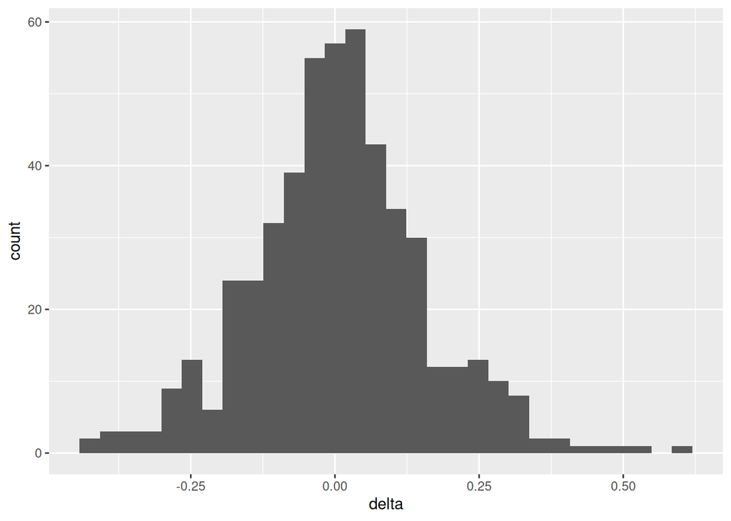

```r
TidyTable<-pivot_longer(W6Data, cols = 2:3, names_to = "Year", values_to = "Nitrogen")
#TidyTable
#differences <- W6Data$SoilN2021 - W6Data$SoilN2018
W6Data<- W6Data |> mutate(delta = W6Data$SoilN2021 - W6Data$SoilN2018)
#W6Data
Histogram1<-ggplot(data=W6Data, mapping = aes(x = delta)) +
  geom_histogram()
Histogram1
```

```r
ks.test(x = W6Data$delta, y = "pnorm", mean(W6Data$delta), sd(W6Data$delta))
```

```
##
##  Asymptotic one-sample Kolmogorov-Smirnov test
##
## data:  W6Data$delta
## D = 0.055508, p-value = 0.09181
## alternative hypothesis: two-sided
```

```r
### This chunk of code is for grading purposes.
### Don't change/delete this chunk of code.
q4 <- Histogram1
```

Question 5: Is the Inorganic Nitrogen data we plan to analyze normally distributed? Answer with a TRUE or FALSE statement.

```r
q5 <- TRUE
```

Question 6: Even if you found the data were normally distributed, lets pretend we need to transform it just for practice. Use the `mutate()` function to create a data column that is transformed InorganicN data. Try a square root transformation this time.

```r
T_Garden_Data<-W6Data |> mutate(sqrt = sqrt(abs(W6Data$delta))) |> select(sqrt)
str(T_Garden_Data)
```

```
## 'data.frame':    500 obs. of  1 variable:
##  $ sqrt: num  0.346 0.359 0.423 0.51 0.148 ...
```

```r
###Explain how you used the mutate function to create a transformed data column
# I once again used pipes, took the Week 6 Dataframe, and then used the mutate function, which the documentation says applies a function to a vector, like the delta column I made in Question 4, and outputs a vector of a new column of the same length with the transformation. From lecture, we know that if we do 'sqrt(data$A)' on a column then it will transform the data by square rooting those values. I got a NaN error if I didn't take the square root of the absolute values of that column, and I used select so that it would return just that column. So this mutates a new sqrt column of the square root of the delta values to the Dataframe, and "selects" that column to store as a vector 'data.frame' in T_Garden_Data.
```

```r
### This chunk of code is for grading purposes.
### Don't change/delete this chunk of code.
q6<- T_Garden_Data
```

Question 7: Is the transformed Inorganic Nitrogen data normally distributed? Use both a histogram and the ks.test() to support your answer.

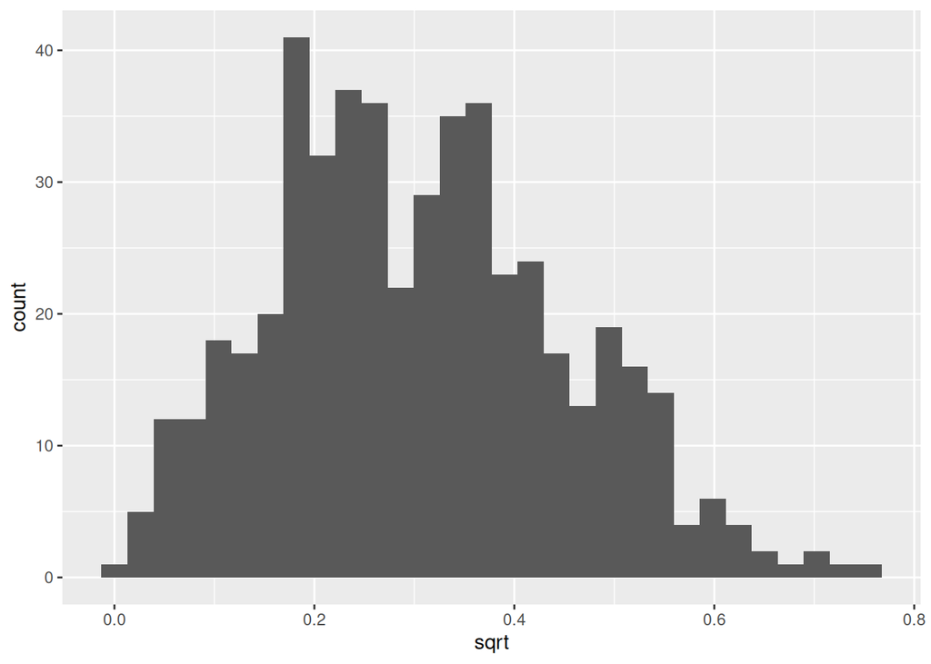

```r
Histogram2<-ggplot(data=T_Garden_Data, mapping = aes(x = sqrt)) +
  geom_histogram()
Histogram2
```

```r
ks.test(x = T_Garden_Data$sqrt, y = "pnorm", mean(T_Garden_Data$sqrt), sd(T_Garden_Data$sqrt))
```

```
##
##  Asymptotic one-sample Kolmogorov-Smirnov test
##
## data:  T_Garden_Data$sqrt
## D = 0.054947, p-value = 0.09768
## alternative hypothesis: two-sided
```

```r
### This chunk of code is for grading purposes.
### Don't change/delete this chunk of code.
q7<- Histogram2
```

Question 8 (1 point): Is the transformed Inorganic Nitrogen data normally distributed? Answer with a TRUE or FALSE statement

```r
q8<- TRUE
```

Question 9: Use the appropriate t test to answer the research question: Is there a difference in inorganic nitrogen content between the two years sampled?

```r
t.test.result<-t.test(W6Data$delta, mu = 0)
#t.test.result<-t.test(W6Data$SoilN2018, W6Data$SoilN2021, paired = TRUE)
#There's no difference, p>0.05 so we fail to reject the null.
t.test.result
```

```
##
##  One Sample t-test
##
## data:  W6Data$delta
## t = 0.99166, df = 499, p-value = 0.3218
## alternative hypothesis: true mean is not equal to 0
## 95 percent confidence interval:
##  -0.006569237  0.019958704
## sample estimates:
##   mean of x
## 0.006694734
```

```r
### This chunk of code is for grading purposes.
### Don't change/delete this chunk of code.
q9<- t.test.result
```

Question 10: Use ggplot to create a boxplot of the data you used in the t test. Make sure your plot is on the correct column(s) of data. Try to make this plot look professional, like we did in week 3! Hint: `geom_boxplot`

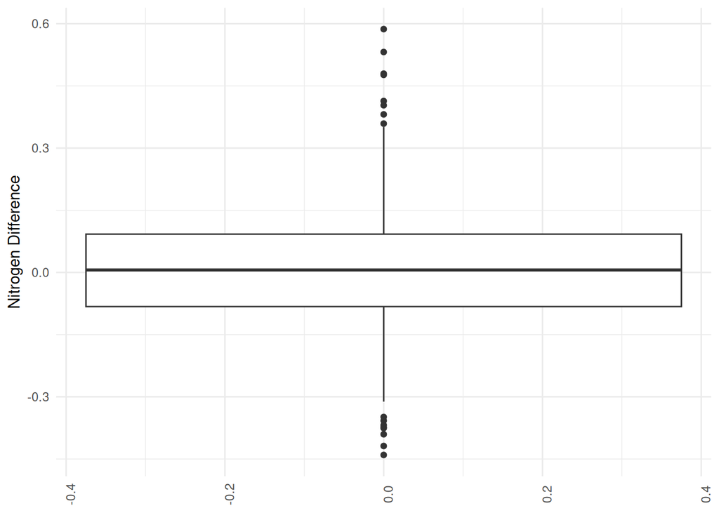

```r
#Boxplot1<-ggplot(data=TidyTable, mapping = aes(x = Year, y = Nitrogen)) +
  #theme_minimal() +
  #theme(axis.text.x = element_text(angle = 90)) +
  #xlab("Year") + # I changed the x-axis label to the year.
  #geom_boxplot()

Boxplot1<-ggplot(data=W6Data, mapping = aes(y = delta)) +
  theme_minimal() + # I set the theme to minimal.
  theme(axis.text.x = element_text(angle = 90)) + # I set the rotation of the x-axis labels to 90 degrees with the element text function.
  ylab("Nitrogen Difference") + # I changed the y-axis label to nitrogen difference instead of 'delta'.
  geom_boxplot() # I set the geometry of the graph type to a box plot.

Boxplot1
```

```r
###Explain the steps you took to generate the boxplot. You can do all of that on this line, or add annotation to each line of your code for this question.

# Explanation: I called ggplot for a box plot graph where I set the data to the new Week 6 Dataframe I made in question 4, with the column for the delta values, and set the mapping aesthetic of the y-axis to this delta column of differences between the two years, like I tested in the paired t-test. The rest of the lines are about the same as Week 3.

#old explanation: I was wrong, it's just one box, not two comparing the years.
# ~~First, I set the data to the TidyTable I made in Question 4, so that it could properly graph the separate year and nitrogen column. Then, I set the mapping of the x column to the year, so I would have my two variables independent variables as 2018 and 2021, and I set the y axis to the nitrogen content.~~
```

```r
### This chunk of code is for grading purposes.
### Don't change/delete this chunk of code.
q9<- Boxplot1
```

Once you are done, knit to make sure you have no errors. Then, save the .rmd file with your name and the week number in the file name:

(for example: “DONE_Liam_Mueller_Section_Assignment_6.rmd”).

Then upload this .rmd file to canvas under the Week 6 module before the deadline.

You are now more than half way done, look how much programming you have learned in this short time! Congratulations, and keep up the good work.